# test_suneris_vgigliobianco

```python
import pandas as pd
from datetime import datetime

import numpy as np

import datetime as dt

import folium
import matplotlib.pyplot as plt
from geopy.distance import geodesic

# from functions import *
from functions import fun as f

%load_ext autoreload
%autoreload 2
```

```
The autoreload extension is already loaded. To reload it, use:
  %reload_ext autoreload
```

```python
df1 = pd.read_csv("data/df1.csv")
df2 = pd.read_csv("data/df2.csv")
df3 = pd.read_csv("data/df3.csv")
df4 = pd.read_csv("data/df4.csv")
df5 = pd.read_csv("data/df5.csv")
df6 = pd.read_csv("data/df6.csv")
```

Création d'un seul dataframe rassemblant toutes les données

```python
df = pd.concat([df1,df2,df3,df4,df5,df6])
```

```python
df.shape
```

```
(1175842, 5)
```

```python
df.head()
```

|  | Unnamed: 0 | id | lat | long | ts |
| --- | --- | --- | --- | --- | --- |
| 0 | 1 | 66 | 48.846460 | 2.306055 | 1556661600 |
| 1 | 2 | 66 | 48.846442 | 2.306054 | 1556661640 |
| 2 | 3 | 66 | 48.846465 | 2.306093 | 1556661690 |
| 3 | 4 | 66 | 48.846485 | 2.306105 | 1556661740 |
| 4 | 5 | 66 | 48.846450 | 2.306070 | 1556661880 |

On voit que le dataset total comprend 1 175 842 observations

Suppression de la 1ère colonne "index" du dataframe

```python
df = df.drop(list(df)[0], axis = 1)
```

**Question 1: quelles sont les étapes du trajet du véhicule n°78 lors de la journée du 2 mai?**

```python
df["date_and_time"] = df["ts"].map(lambda x:datetime.fromtimestamp(x))
df['year'] = df['date_and_time'].dt.year
df['month'] = df['date_and_time'].dt.month
df['day'] = df['date_and_time'].dt.day

df['hour'] = df['date_and_time'].dt.hour
df['min'] = df['date_and_time'].dt.minute
df['sec'] = df['date_and_time'].dt.second
```

On considère le véhicule avec l'id n°78

```python
df_id_78 = df[(df["id"] == 78) & (df["year"] == 2019) & (df["month"] == 5) & (df["day"] == 2)]
```

Ci-dessous, la visualisation de tous les couples de latitude, longitude pour le véhicule n°78

```python
points = [(row.lat,row.long) for row in df_id_78.itertuples()]
my_map = folium.Map(location = points[0], zoom_start=12)
folium.PolyLine(points,color = "red").add_to(my_map)
display(my_map)
```

[interactive chart not shown]

On voit que le véhicule n°78 lors de ses déplacements, passe par:

- quartier Arts et Métiers
- rue de Rivoli
- Champs Elysées
- demi-tour à hauteur de rue de la Boétie
- rue du Faubourg Saint Honoré
- passage par La Madeleine + Opéra + Bourse + rue Réaumur
- quartier Arts et Métiers

Mais il convient de définir exactement quand le véhicule a effectué ces déplacements.  
Comme le trajet du véhicule n°78 est un trajet qui constitue une boucle, on peut se demander si le véhicule fait des poses et reste par moments immobile

On crée un vecteur contenant la vitesse entre deux points consécutifs  
On peut tracer sa vitesse au cours du temps t

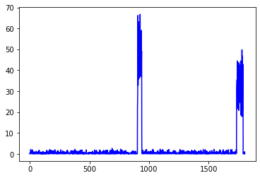

```python
all_ts = [each for each in df_id_78.ts]
durees = [(all_ts[i] - all_ts[i-1])/3600 for i in range(0,len(all_ts))]

all_pts = []
for row in df_id_78.itertuples():
    all_pts.append((row.lat, row.long))
distances = [geodesic(all_pts[i],all_pts[i-1]).kilometers for i in range(0,len(all_pts))]
vitesses = [distances[i]/durees[i] for i in range(0,len(distances))]
t = [each for each in range(0,len(all_ts))]
plt.plot(t,vitesses,color='blue')
plt.xticks(np.arange(0, 1804, step=500))
plt.show()
```

Identifions ces pics de vitesse

```python
id_ts_pic_vitesses = []
id_ts = 0
for each in vitesses:
    if each >=20:
        id_ts_pic_vitesses.append(id_ts)
    id_ts += 1
```

```python
id_ts_pic_vitesses
```

```
[903,
 904,
 905,
 906,
 907,
 908,
 909,
 910,
 911,
 912,
 913,
 914,
 915,
 916,
 917,
 918,
 919,
 920,
 921,
 922,
 923,
 924,
 925,
 926,
 927,
 928,
 929,
 930,
 931,
 932,
 933,
 934,
 935,
 936,
 937,
 938,
 1734,
 1735,
 1736,
 1737,
```

[output cut: 32 more lines]

```
 1771,
 1772,
 1773,
 1774,
 1776,
 1777,
 1779,
 1781,
 1782,
 1783,
 1784,
 1785,
 1786,
 1787,
 1788]
```

On voit que la vitesse est supérieure à 20 km/h lorsque:

- les identifiants des timestamps sont compris entre 903 et 938
- et lorsque les identifiants des timestamps sont compris entre 1734 et 1788

```python
df_id_78[df_id_78["ts"].isin([all_ts[0],all_ts[903],all_ts[938],all_ts[1734],all_ts[1788],all_ts[len(all_ts)-1]])]
```

|  | id | lat | long | ts | date_and_time | year | month | day | hour | min | sec |
| --- | --- | --- | --- | --- | --- | --- | --- | --- | --- | --- | --- |
| 69616 | 78 | 48.869056 | 2.297370 | 1556748000 | 2019-05-02 00:00:00 | 2019 | 5 | 2 | 0 | 0 | 0 |
| 70519 | 78 | 48.868362 | 2.298619 | 1556793090 | 2019-05-02 12:31:30 | 2019 | 5 | 2 | 12 | 31 | 30 |
| 70554 | 78 | 48.865636 | 2.355413 | 1556793440 | 2019-05-02 12:37:20 | 2019 | 5 | 2 | 12 | 37 | 20 |
| 71350 | 78 | 48.865022 | 2.354203 | 1556832910 | 2019-05-02 23:35:10 | 2019 | 5 | 2 | 23 | 35 | 10 |
| 71404 | 78 | 48.869101 | 2.297463 | 1556833450 | 2019-05-02 23:44:10 | 2019 | 5 | 2 | 23 | 44 | 10 |
| 71419 | 78 | 48.869078 | 2.297439 | 1556834350 | 2019-05-02 23:59:10 | 2019 | 5 | 2 | 23 | 59 | 10 |

On peut alors visualiser les différentes étapes du trajet du véhicule

```python
points = [(row.lat,row.long) for row in df_id_78.itertuples()]
```

Ci-dessous, **l'étape n°1** correspondant aux dates comprises entre 2019-05-02 00:00:00 et 2019-05-02 12:31:30

```python
map = folium.Map(location= points[0], zoom_start=12)
for i in range(0,903):
    folium.Marker(location = points[i], icon=folium.Icon(color='red')).add_to(map)
(map)
```

[interactive chart not shown]

On voit sur le graphe ci-dessus que pour cette **étape n°1**, le véhicule reste à proximité de la rue Jean Giraudoux

Ci-dessous, **l'étape n°2** correspondant aux dates comprises entre 2019-05-02 12:31:30 et 2019-05-02 12:37:20

```python
my_map = folium.Map(location = points[0], zoom_start=12)
folium.PolyLine(points[903:938], color = "red").add_to(my_map)
display(my_map)
```

[interactive chart not shown]

Lors de **l'étape n°2**, le véhicule se déplace du qurtier des Champs Elysées, en passant par rue du Faubourg Saint Honoré, Madeleine, Bourse puis rue Réaumur  
et atteindre le quartier des Arts et Métiers

Ci-dessous, **l'étape n°3** correspondant aux dates comprises entre 2019-05-02 12:37:20 et 2019-05-02 23:35:10

```python
map = folium.Map(location= points[0], zoom_start=12)
for i in range(938,1734):
    folium.Marker(location = points[i],icon=folium.Icon(color='red')).add_to(map)
(map)
```

[interactive chart not shown]

On voit sur le graphe ci-dessus que pour **l'étape n°3**, le véhicule s'est très peu déplacé et est resté à proximité de Réaumur Sébastopol et rue Turbigo:  
Le véhicule est donc resté proche du quartier des Arts et Métiers, entre 2019-05-02 12:37:20 et 2019-05-02 23:35:10

Ci-dessous, **l'étape n°4** correspondant aux dates comprises entre 2019-05-02 23:35:10 et 2019-05-02 23:44:10

```python
my_map = folium.Map(location = points[0], zoom_start=12)
folium.PolyLine(points[1734:1788],color = "red").add_to(my_map)
display(my_map)
```

[interactive chart not shown]

Cette **étape n°4** correspond à son trajet retour entre 2019-05-02 23:35:10 et 2019-05-02 23:44:10  
Cette fois, pour le trajet retour, il est passé par :

- rue de Turbigo
- rue Etienne Marcel
- rue du Louvre
- rue de Rivoli
- les Champs Elysées

Enfin, les derniers timestamps ci-dessous, indiquent que le véhicule est resté proche de la rue Jean Giraudoux et du quartier des Champs Elysées  
entre 2019-05-02 23:44:10 et 2019-05-02 23:59:10  
Ceci correspond à **l'étape n°5**

```python
map = folium.Map(location= points[0], zoom_start=12)
for i in range(1788,len(points)):
    folium.Marker(location = points[i],icon=folium.Icon(color='red')).add_to(map)
display(map)
```

[interactive chart not shown]

**Question 2: quel est, à priori, le garage principal du véhicule n°57?**

```python
df[df["id"] == 57].head()
```

|  | id | lat | long | ts | date_and_time | year | month | day | hour | min | sec |
| --- | --- | --- | --- | --- | --- | --- | --- | --- | --- | --- | --- |
| 52666 | 57 | 43.597116 | 1.443342 | 1556661660 | 2019-05-01 00:01:00 | 2019 | 5 | 1 | 0 | 1 | 0 |
| 52667 | 57 | 43.597119 | 1.443341 | 1556661740 | 2019-05-01 00:02:20 | 2019 | 5 | 1 | 0 | 2 | 20 |
| 52668 | 57 | 43.597125 | 1.443347 | 1556661750 | 2019-05-01 00:02:30 | 2019 | 5 | 1 | 0 | 2 | 30 |
| 52669 | 57 | 43.597093 | 1.443387 | 1556661770 | 2019-05-01 00:02:50 | 2019 | 5 | 1 | 0 | 2 | 50 |
| 52670 | 57 | 43.597126 | 1.443369 | 1556661810 | 2019-05-01 00:03:30 | 2019 | 5 | 1 | 0 | 3 | 30 |

Un "garage" peut être identifié comme une localisation qui doit être visible pour chaque jour

Les trajets du véhicule pour chaque jour, peuvent être superposés, de manière à identifier un garage  
comme étant un point commun aux cinq trajets correspondant à chaque jour, c'est-à-dire au 01/05/2019, 02/05/2019, 03/05/2019, 04/05/2019 et 05/05/2019

```python
df_id_57_day_1 = df[(df["id"] == 57) & (df["year"] == 2019) & (df["month"] == 5) & (df["day"] == 1)]
df_id_57_day_2 = df[(df["id"] == 57) & (df["year"] == 2019) & (df["month"] == 5) & (df["day"] == 2)]
df_id_57_day_3 = df[(df["id"] == 57) & (df["year"] == 2019) & (df["month"] == 5) & (df["day"] == 3)]
df_id_57_day_4 = df[(df["id"] == 57) & (df["year"] == 2019) & (df["month"] == 5) & (df["day"] == 4)]
df_id_57_day_5 = df[(df["id"] == 57) & (df["year"] == 2019) & (df["month"] == 5) & (df["day"] == 5)]
points_1 = [(row.lat,row.long) for row in df_id_57_day_1.itertuples()]
points_2 = [(row.lat,row.long) for row in df_id_57_day_2.itertuples()]
points_3 = [(row.lat,row.long) for row in df_id_57_day_3.itertuples()]
points_4 = [(row.lat,row.long) for row in df_id_57_day_4.itertuples()]
points_5 = [(row.lat,row.long) for row in df_id_57_day_5.itertuples()]
my_map = folium.Map(location = points_1[0], zoom_start=12)
folium.PolyLine(points_1,color = "red").add_to(my_map)
folium.PolyLine(points_2,color = "blue").add_to(my_map)
folium.PolyLine(points_3,color = "orange").add_to(my_map)
folium.PolyLine(points_4,color = "green").add_to(my_map)
folium.PolyLine(points_5,color = "black").add_to(my_map)
display(my_map)
```

[interactive chart not shown]

En superposant les trajets de chaque jour du véhicule n°57, nous constatons que les trajets du véhicule ont lieu dans la ville de Toulouse  
On s'aperçoit qu'il y a une convergence de tous les trajets vers une localisation

Ci-dessous, une copie d'écran de cette localisation, obtenue en zoomant sur cette zone:

[figure not shown]

On peut maintenant considérer un trajet, par exemple celui du jour n°1

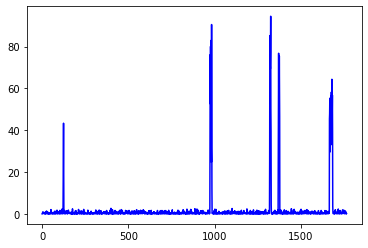

```python
all_ts = [each for each in df_id_57_day_1.ts]
durees = [(all_ts[i] - all_ts[i-1])/3600 for i in range(0,len(all_ts))]

all_pts = []
for row in df_id_57_day_1.itertuples():
    all_pts.append((row.lat, row.long))
distances = [geodesic(all_pts[i],all_pts[i-1]).kilometers for i in range(0,len(all_pts))]
vitesses = [distances[i]/durees[i] for i in range(0,len(distances))]
t = [each for each in range(0,len(all_ts))]
plt.plot(t,vitesses, color = 'blue')
plt.xticks(np.arange(0, len(all_ts), step=500))
plt.show()
```

Ci-dessous les points correspondant à des localisations où la vitesse du véhicule est faible

```python
df_id_57_day_1[df_id_57_day_1["ts"].isin([all_ts[50],all_ts[500],all_ts[1100],all_ts[1500]])]
```

|  | id | lat | long | ts | date_and_time | year | month | day | hour | min | sec |
| --- | --- | --- | --- | --- | --- | --- | --- | --- | --- | --- | --- |
| 52716 | 57 | 43.597086 | 1.443379 | 1556664610 | 2019-05-01 00:50:10 | 2019 | 5 | 1 | 0 | 50 | 10 |
| 53166 | 57 | 43.593613 | 1.443912 | 1556687040 | 2019-05-01 07:04:00 | 2019 | 5 | 1 | 7 | 4 | 0 |
| 53766 | 57 | 43.605331 | 1.437606 | 1556716760 | 2019-05-01 15:19:20 | 2019 | 5 | 1 | 15 | 19 | 20 |
| 54166 | 57 | 43.611248 | 1.430932 | 1556736000 | 2019-05-01 20:40:00 | 2019 | 5 | 1 | 20 | 40 | 0 |

On peut alors visualiser sur le graphe ci-dessous, les quatres différentes localisations possibles du "garage principal"

```python
points = [(row.lat,row.long) for row in df_id_57_day_1.itertuples()]
```

```python
map = folium.Map(location= points[0], zoom_start=12)
folium.Marker(location = points[50],icon=folium.Icon(color='green')).add_to(map)
folium.Marker(location = points[500],icon=folium.Icon(color='red')).add_to(map)
folium.Marker(location = points[1100],icon=folium.Icon(color='blue')).add_to(map)
folium.Marker(location = points[1500],icon=folium.Icon(color='orange')).add_to(map)
(map)
```

[interactive chart not shown]

```python
print (points[500])
```

```
(43.593613266617005, 1.44391168173437)
```

Le garage principal pour le véhicule n°57 a donc pour latitude et longitude :

```
    - latitude : 43.593613266617005
    - longitude : 1.44391168173437
```

Ce garage principal est situé à Toulouse à l'intersection de la rue Saint Jean / rue des Prêtres et de la rue Saint Rémésy

**Question 3: si N véhicules (N>1) se déplacent ensemble sur une distance plus ou moins longue la même journée, ils forment un convoi. Identifiez les convois de la journée du 4 mai.**

##### L'idée que je souhaite mettre en place est d'extraire tous les positions des véhicules pour chaque date $t$ espacée d'un pas $h = 5$ (minutes)

Une fois toutes ces positions obtenues, on peut en déduire les identifiants des véhicules.  
En agrégeant les véhicules qui sont en commun entre deux dates successives, on peut alors identifier les listes de véhicules pouvant former un convoi.

**Idée algorithme (pseudo-code)**:  
Si $t_{debut}$ = date de début de la période totale et $t_{fin}$ = date de fin de la période totale

Ci-dessous, le pseudo-code que j'ai décidé d'implémenter afin d'identifier tous les groupes de véhicules qui restent très proches entre eux au cours du temps

1. Obtention de points voisins pour chaque timestamp $t$

   KDTree est une méthode adaptée à la problématique car c'est une méthode de recherche rapide de plus proches voisins.  
   L'algorithme de KDTree est directement utilisable via la librairie Pysal de Python.  
   On va considérer tous les timestamps $t$ compris entre $[t_{debut};t_{fin}]$ et espacés d'un pas $h = 5$ (minutes):  
   Pour un point donné $x_0$ défini par sa latitude et sa longitude, KDTree va permettre d'extraire tous les points situés à une distance inférieure à $\epsilon$ de $x_0$ (on choisit comme unité de distance les km)  
   On va lancer KDTree de paramètre $\epsilon$ pour chaque date $t$ et donc pour chaque point $x_0$ défini par une latitude et une longitude, afin d'extraire tous les points voisins de $x_0$ qui sont à une distance inférieure à $\epsilon$ km.  
   On obtient pour chaque date $t$, des ensembles de points, chacun de ces ensembles constituant un ensemble de points voisins l'un de l'autre  
   c'est-à-dire, distants l'un de l'autre de moins de $\epsilon$ km
2. Obtention des convois de durée minimale

   On fixe la date initiale $t_1$ comprise entre $[t_{debut} ;t_{fin}]$  
   On considère $\delta t$ la durée du convoi minimale égale à 5 minutes  
   avec : $t_2 = t_1 + \delta t$

   ```
    - On part de la date $t_1$ et on fait varier $t_1$<br>
    - On utilise les listes de véhicules obtenues grâce à l'étape 1., qui sont voisins pour tous ces couples de dates $t_1$ et $t_2$<br>
    - On fait varier $t_1$ afin d'obtenir tous les convois qui ont lieu durant la plus petite durée égale à $\delta t = 5$ minutes<br>
    - On a obtenu alors pour chaque date $t_1$ et $t_2$ les listes de véhicules voisins l'un de l'autre.<br>
   ```

3. Obtention d'une liste de véhicules candidats pour un convoi
   - On part de la date $t_1$
   - On boucle pour chaque date $t = t_1 + p*pas$ comprise entre $t_{debut}$ et $t_{fin}$, avec $pas = 5$ minutes et $p$ entier:

     ```
      - Tant qu'il existe une intersection non vide :<br>
      <br>
       - agréger entre $t_1$ et $t_1 + pas$, les listes de véhicules correspondant à la date $t$ et les listes des véhicules correspondant à la date $t + pas$<br>
       - agréger le résultat obtenu avec les listes de véhicules obtenues pour $t_1 + 2*pas$<br>
       - agréger le résultat obtenu avec les listes de véhicules obtenues pour $t_1 + 3*pas$<br>
       - Etc...<br>
      <br>
     ```

   - On obtient une liste de véhicules candidats pour un convoi
4. Evaluation de la vitesse des convois

   Le résultat final correspond aux convois candidats possédant une vitesse supérieure à un seuil  
   Exemple : seuil = 5 km/h

**Etape 1: obtention de points voisins pour chaque timestamp t**

- Filtre pour la journée du 4 mai pour obtenir le dataframe "df_journee_4_mai"
- Extraction de tous les timestamps dans le dictionnaire "all_datetimes"
- Extraction avec KDTree (en utilisant l'hyperparamètre de KDTree $\epsilon$) de tous les points voisins des points à timestamps espacés de $h = 5$ minutes

```python
%%time

df_journee_4_mai = df[(df["year"] == 2019) & (df["month"] == 5) & (df["day"] == 4)]

all_datetimes = []
# Dictionnaire "all_datetimes_temp" améliorant la performance pour dédoublonnage des dates
all_datetimes_temp = {}
for row in df_journee_4_mai.itertuples():
    if row.date_and_time not in all_datetimes_temp.keys():
        all_datetimes.append(row.date_and_time)
        # la valeur : 148.8412620324593, 2.3319375336731802 ici n'a pas d'importance
        all_datetimes_temp[row.date_and_time] = 148.8412620324593, 2.3319375336731802
```

```
CPU times: user 2.25 s, sys: 15.3 ms, total: 2.26 s
Wall time: 2.31 s
```

Création du dictionnaire "dict_datetimes_h" des dates $t$ espacées de $h = 5$ (minutes)

```python
%%time
dict_datetimes_h = {}

h = 5
i = 0

# 1ère date
dict_datetimes_h[i] = all_datetimes[0]
print (dict_datetimes_h[i])

# Dernière date
print (all_datetimes[len(all_datetimes) -1])

while (dict_datetimes_h[i] <= all_datetimes[len(all_datetimes) -1]):
    i += 1
    dict_datetimes_h[i] = dict_datetimes_h[i-1] + dt.timedelta(minutes = h)
```

```
2019-05-04 00:00:40
2019-05-04 23:49:30
CPU times: user 3.03 ms, sys: 80 µs, total: 3.11 ms
Wall time: 2.88 ms
```

Extraction de tous les points voisins des points à timestamps espacés de $h = 5$ minutes  
On choisit $\epsilon = 50$ mètres comme "hyperparamètre" de KDTree  
On obtient en sortie le dictionnaire "dict_pts_found_with_id" pour tous les timestamps espacés de $h = 5$ minutes des identifiants des véhicules qui sont distants de moins de $\epsilon = 50$ mètres

```python
%%time

epsilon = 0.05 # 50 mètres
dict_pts_found_with_id = f.get_voisins_with_kdtree(epsilon,df_journee_4_mai,dict_datetimes_h)
```

```
CPU times: user 11.8 s, sys: 20 ms, total: 11.8 s
Wall time: 11.8 s
```

Les dates $t_{debut}$ et $t_{fin}$ sont:

```python
t_debut = [k for k in dict_pts_found_with_id.keys()][0]
t_fin = max([k for k in dict_pts_found_with_id.keys()])
print (t_debut,t_fin)
```

```
2019-05-04 00:00:40 2019-05-04 23:50:40
```

**Etape 2: obtention des convois de durée minimale**

On choisit un intervalle de temps $[t_1;t_2]$. On prend d'abord: $t_1 = t_{debut}$. On définit un intervalle de temps "minimal" égal à 5 minutes, c'est la durée $\delta t$.  
On calcule $t_2 = t_1 + \delta t$ avec $\delta t = 5$ minutes. On pourra faire varier la date $t_1$ afin de trouver tous les convois de durée minimale $\delta t$

Exemple:

- $t_1 = t_{debut}$
- $t_2 = t_1 + \delta t$

```python
t1 = t_debut
delta_t = dt.timedelta(minutes = 5)
t2 = t1 + delta_t
print (t1)
print (t2)
```

```
2019-05-04 00:00:40
2019-05-04 00:05:40
```

Création du dictionnaire "dict_dates_to_id" qui fait correspondre à un timestamp, la position du timestamp dans le dictionnaire "dict_pts_found_with_id"

```python
%%time
dict_dates_to_id = {}
i = 0
for each_date in [k for k in dict_pts_found_with_id.keys()]:
    dict_dates_to_id[each_date] = i
    i += 1
```

```
CPU times: user 148 µs, sys: 4 µs, total: 152 µs
Wall time: 155 µs
```

On doit faire varier $t_1$ qui prend toutes les valeurs espacées de $h = 5$ (minutes) comprises entre $t_{debut}$ et $t_{fin}$  
Ici: $\delta t = 5$ minutes, on recherche tous les convois qui durent 5 minutes

On va utiliser comme "hyperparamètres" les valeurs:

- $\epsilon = 0.05$ (km)
- $h = 5$ minutes
- on fait varier $t_1$ entre : '2019-05-04 00:00:40' et '2019-05-04 23:50:40'
- $\delta t = 5$ minutes  
  Mais on pourrait faire varier ces hyperparamètres si nécessaire

```python
%%time

delta_t = dt.timedelta(minutes = 5)

dict_resultats = {}
for t1 in [k for k in dict_pts_found_with_id.keys()]:
    t2 = t1 + delta_t
    # Stockage des résultats
    #if t2 < t_fin
    if t2 < max(list(dict_pts_found_with_id.keys())):
        if f.get_all_convois(t1,t2,dict_dates_to_id,dict_pts_found_with_id) != [] :
            dict_resultats[t1,t2, delta_t] = f.get_all_convois(t1,t2,dict_dates_to_id,dict_pts_found_with_id)
```

```
CPU times: user 33.6 ms, sys: 29 µs, total: 33.7 ms
Wall time: 33 ms
```

**Etape 3: obtention d'une liste de véhicules candidats pour un convoi**

```python
%%time
h = dt.timedelta(minutes = 5)
resultat_final = f.get_final_result(dict_resultats,h)
```

```
CPU times: user 985 µs, sys: 26 µs, total: 1.01 ms
Wall time: 1.02 ms
```

```python
#resultat_final
```

**Etape 4: évaluation de la vitesse des convois**

Calcul des vitesses d'un représentant:  
on tire au hasard un id de véhicule parmi la liste des vehicules et on calcule de la vitesse entre la date de début et la date de fin de chaque intervalle  
On choisit de ne garder que les convois avec vitesse supérieure ou égale à 5 km/h

```python
df.head()
```

|  | id | lat | long | ts | date_and_time | year | month | day | hour | min | sec |
| --- | --- | --- | --- | --- | --- | --- | --- | --- | --- | --- | --- |
| 0 | 66 | 48.846460 | 2.306055 | 1556661600 | 2019-05-01 00:00:00 | 2019 | 5 | 1 | 0 | 0 | 0 |
| 1 | 66 | 48.846442 | 2.306054 | 1556661640 | 2019-05-01 00:00:40 | 2019 | 5 | 1 | 0 | 0 | 40 |
| 2 | 66 | 48.846465 | 2.306093 | 1556661690 | 2019-05-01 00:01:30 | 2019 | 5 | 1 | 0 | 1 | 30 |
| 3 | 66 | 48.846485 | 2.306105 | 1556661740 | 2019-05-01 00:02:20 | 2019 | 5 | 1 | 0 | 2 | 20 |
| 4 | 66 | 48.846450 | 2.306070 | 1556661880 | 2019-05-01 00:04:40 | 2019 | 5 | 1 | 0 | 4 | 40 |

```python
resultat_final_vitesse = f.get_convoi_with_vitesse(df,resultat_final,5)
```

```
[0, 41, 62, 99, 1014] avec vitesse  13 km/h et entre les dates:  2019-05-04 05:10:40 et  2019-05-04 05:20:40
[0, 41, 62, 99, 1014] avec vitesse  15 km/h et entre les dates:  2019-05-04 05:10:40 et  2019-05-04 05:25:40
[62, 1014] avec vitesse  12 km/h et entre les dates:  2019-05-04 05:10:40 et  2019-05-04 05:30:40
[0, 7, 21, 25, 26, 31, 32, 40, 41, 49, 50, 54, 55, 62, 80, 82, 90, 92, 99, 102, 111, 1000, 1014] avec vitesse  22 km/h et entre les dates:  2019-05-04 05:15:40 et  2019-05-04 05:25:40
[32, 54, 62, 1014] avec vitesse  15 km/h et entre les dates:  2019-05-04 05:15:40 et  2019-05-04 05:30:40
[32, 54, 62, 1014] avec vitesse  10 km/h et entre les dates:  2019-05-04 05:20:40 et  2019-05-04 05:30:40
```

J'obtiens donc comme convois du durée maximale pour le 4 mai 2019:

- [0, 41, 62, 99, 1014] avec vitesse 15 km/h et entre les dates: 2019-05-04 05:10:40 et 2019-05-04 05:25:40
- [62, 1014] avec vitesse 12 km/h et entre les dates: 2019-05-04 05:10:40 et 2019-05-04 05:30:40
- [0, 7, 21, 25, 26, 31, 32, 40, 41, 49, 50, 54, 55, 62, 80, 82, 90, 92, 99, 102, 111, 1000, 1014] avec vitesse 22 km/h et entre les dates: 2019-05-04 05:15:40 et 2019-05-04 05:25:40
- [32, 54, 62, 1014] avec vitesse 15 km/h et entre les dates: 2019-05-04 05:15:40 et 2019-05-04 05:30:40

**Question 4: identifiez le couple de véhicules formant le plus souvent un convoi entre le 1er et le 5 mai.**

On relance tout cette fois en considérant en entrée toutes les données présentes dans le dataframe "df"

```python
df.tail()
```

|  | id | lat | long | ts | date_and_time | year | month | day | hour | min | sec |
| --- | --- | --- | --- | --- | --- | --- | --- | --- | --- | --- | --- |
| 175832 | 17 | 43.597858 | 1.432142 | 1557093290 | 2019-05-05 23:54:50 | 2019 | 5 | 5 | 23 | 54 | 50 |
| 175833 | 17 | 43.597864 | 1.432138 | 1557093360 | 2019-05-05 23:56:00 | 2019 | 5 | 5 | 23 | 56 | 0 |
| 175834 | 17 | 43.597842 | 1.432121 | 1557093430 | 2019-05-05 23:57:10 | 2019 | 5 | 5 | 23 | 57 | 10 |
| 175835 | 17 | 43.597829 | 1.432091 | 1557093560 | 2019-05-05 23:59:20 | 2019 | 5 | 5 | 23 | 59 | 20 |
| 175836 | 17 | 43.597861 | 1.432113 | 1557093580 | 2019-05-05 23:59:40 | 2019 | 5 | 5 | 23 | 59 | 40 |

```python
%%time

all_datetimes = []
# Dictionnaire "all_datetimes_temp" améliorant la performance pour dédoublonnage des dates
all_datetimes_temp = {}
for row in df.itertuples():
    if row.date_and_time not in all_datetimes_temp.keys():
        all_datetimes.append(row.date_and_time)
        # la valeur : 148.8412620324593, 2.3319375336731802 ici n'a pas d'importance
        all_datetimes_temp[row.date_and_time] = 148.8412620324593, 2.3319375336731802

dict_datetimes_h = {}

h = 5
i = 0

# 1ère date
dict_datetimes_h[i] = all_datetimes[0]
print (dict_datetimes_h[i])

# Dernière date
sorted_all_datetimes = sorted(all_datetimes)
print (sorted_all_datetimes[len(sorted_all_datetimes) -1])

while (dict_datetimes_h[i] <= sorted_all_datetimes[len(sorted_all_datetimes) -1]):
    i += 1
    dict_datetimes_h[i] = dict_datetimes_h[i-1] + dt.timedelta(minutes = h)

epsilon = 0.05 # 50 mètres
dict_pts_found_with_id = f.get_voisins_with_kdtree(epsilon,df,dict_datetimes_h)
```

```
2019-05-01 00:00:00
2019-05-05 23:59:50
CPU times: user 1min 20s, sys: 306 ms, total: 1min 21s
Wall time: 1min 21s
```

```python
%%time
len(dict_pts_found_with_id)
```

```
CPU times: user 7 µs, sys: 0 ns, total: 7 µs
Wall time: 12.9 µs
```

```
1441
```

```python
%%time
t_debut = [k for k in dict_pts_found_with_id.keys()][0]
t_fin = [k for k in dict_pts_found_with_id.keys()][len(dict_pts_found_with_id) - 1]
print (t_debut,t_fin)
```

```
2019-05-01 00:00:00 2019-05-06 00:00:00
CPU times: user 772 µs, sys: 15 µs, total: 787 µs
Wall time: 795 µs
```

```python
%%time
dict_dates_to_id = {}
i = 0
for each_date in [k for k in dict_pts_found_with_id.keys()]:
    dict_dates_to_id[each_date] = i
    i += 1
```

```
CPU times: user 801 µs, sys: 0 ns, total: 801 µs
Wall time: 922 µs
```

```python
%%time

delta_t = dt.timedelta(minutes = 5)

dict_resultats = {}
for t1 in [k for k in dict_pts_found_with_id.keys()]:
    t2 = t1 + delta_t

    if t2 < max(list(dict_pts_found_with_id.keys())):
        if f.get_all_convois(t1,t2,dict_dates_to_id,dict_pts_found_with_id) != [] :
            # Stockage des résultats
            dict_resultats[t1,t2, delta_t] = f.get_all_convois(t1,t2,dict_dates_to_id,dict_pts_found_with_id)
```

```
CPU times: user 673 ms, sys: 0 ns, total: 673 ms
Wall time: 695 ms
```

```python
%%time
h = dt.timedelta(minutes = 5)
resultat_final = f.get_final_result(dict_resultats,h)
```

```
CPU times: user 4.26 ms, sys: 4 µs, total: 4.26 ms
Wall time: 4.47 ms
```

```python
resultat_final_vitesse = f.get_convoi_with_vitesse(df,resultat_final,5)
```

```
[2, 31, 36, 43, 103, 104, 108, 113, 1024] avec vitesse  13 km/h et entre les dates:  2019-05-01 01:50:00 et  2019-05-01 02:00:00
[2, 31, 36, 43, 103, 104, 108, 113, 1024] avec vitesse  15 km/h et entre les dates:  2019-05-01 01:50:00 et  2019-05-01 02:05:00
[2, 16, 31, 36, 43, 44, 54, 64, 77, 84, 103, 104, 105, 108, 111, 113, 119, 1003, 1024] avec vitesse  21 km/h et entre les dates:  2019-05-01 01:55:00 et  2019-05-01 02:05:00
[31, 77] avec vitesse  19 km/h et entre les dates:  2019-05-01 01:55:00 et  2019-05-01 02:10:00
[31, 77] avec vitesse  19 km/h et entre les dates:  2019-05-01 02:00:00 et  2019-05-01 02:10:00
[3, 19, 36, 43, 111] avec vitesse  18 km/h et entre les dates:  2019-05-02 16:20:00 et  2019-05-02 16:30:00
[3, 19, 36, 43, 111] avec vitesse  20 km/h et entre les dates:  2019-05-02 16:20:00 et  2019-05-02 16:35:00
[3, 16, 18, 19, 31, 36, 43, 62, 65, 77, 84, 87, 91, 97, 111, 113, 114, 1000, 1003, 1004, 1007, 1022] avec vitesse  24 km/h et entre les dates:  2019-05-02 16:25:00 et  2019-05-02 16:35:00
[31, 77, 84, 113, 1003, 1022] avec vitesse  18 km/h et entre les dates:  2019-05-02 16:25:00 et  2019-05-02 16:40:00
[31, 77, 84, 113, 1003, 1022] avec vitesse  15 km/h et entre les dates:  2019-05-02 16:30:00 et  2019-05-02 16:40:00
[49, 65] avec vitesse  22 km/h et entre les dates:  2019-05-03 02:05:00 et  2019-05-03 02:15:00
[7, 51, 82, 1014] avec vitesse  27 km/h et entre les dates:  2019-05-03 05:00:00 et  2019-05-03 05:10:00
[62, 99] avec vitesse  12 km/h et entre les dates:  2019-05-04 05:10:00 et  2019-05-04 05:20:00
[62, 99] avec vitesse  15 km/h et entre les dates:  2019-05-04 05:10:00 et  2019-05-04 05:25:00
[62, 99, 102] avec vitesse  22 km/h et entre les dates:  2019-05-04 05:15:00 et  2019-05-04 05:25:00
[25, 26, 40, 80, 90, 92] avec vitesse  12 km/h et entre les dates:  2019-05-04 05:20:00 et  2019-05-04 05:30:00
[70, 84, 1003] avec vitesse  12 km/h et entre les dates:  2019-05-04 14:45:00 et  2019-05-04 14:55:00
[111, 113] avec vitesse  15 km/h et entre les dates:  2019-05-05 12:40:00 et  2019-05-05 12:50:00
[25, 77, 102, 1004] avec vitesse  20 km/h et entre les dates:  2019-05-05 21:15:00 et  2019-05-05 21:25:00
[0, 1004] avec vitesse  16 km/h et entre les dates:  2019-05-05 21:20:00 et  2019-05-05 21:30:00
```

Ci-dessous, les convois entre le 1er et le 5 mai que j'obtiens et qui ont des durées maximales:

- [2, 31, 36, 43, 103, 104, 108, 113, 1024] avec vitesse 15 km/h et entre les dates: 2019-05-01 01:50:00 et 2019-05-01 02:05:00
- [2, 16, 31, 36, 43, 44, 54, 64, 77, 84, 103, 104, 105, 108, 111, 113, 119, 1003, 1024] avec vitesse 21 km/h et entre les dates: 2019-05-01 01:55:00 et 2019-05-01 02:05:00
- [31, 77] avec vitesse 19 km/h et entre les dates: 2019-05-01 01:55:00 et 2019-05-01 02:10:00
- [3, 19, 36, 43, 111] avec vitesse 20 km/h et entre les dates: 2019-05-02 16:20:00 et 2019-05-02 16:35:00
- [3, 16, 18, 19, 31, 36, 43, 62, 65, 77, 84, 87, 91, 97, 111, 113, 114, 1000, 1003, 1004, 1007, 1022] avec vitesse 24 km/h et entre les dates: 2019-05-02 16:25:00 et 2019-05-02 16:35:00
- [31, 77, 84, 113, 1003, 1022] avec vitesse 18 km/h et entre les dates: 2019-05-02 16:25:00 et 2019-05-02 16:40:00
- [49, 65] avec vitesse 22 km/h et entre les dates: 2019-05-03 02:05:00 et 2019-05-03 02:15:00
- [7, 51, 82, 1014] avec vitesse 27 km/h et entre les dates: 2019-05-03 05:00:00 et 2019-05-03 05:10:00
- [62, 99] avec vitesse 15 km/h et entre les dates: 2019-05-04 05:10:00 et 2019-05-04 05:25:00
- [62, 99, 102] avec vitesse 22 km/h et entre les dates: 2019-05-04 05:15:00 et 2019-05-04 05:25:00
- [25, 26, 40, 80, 90, 92] avec vitesse 12 km/h et entre les dates: 2019-05-04 05:20:00 et 2019-05-04 05:30:00
- [70, 84, 1003] avec vitesse 12 km/h et entre les dates: 2019-05-04 14:45:00 et 2019-05-04 14:55:00
- [111, 113] avec vitesse 15 km/h et entre les dates: 2019-05-05 12:40:00 et 2019-05-05 12:50:00
- [25, 77, 102, 1004] avec vitesse 20 km/h et entre les dates: 2019-05-05 21:15:00 et 2019-05-05 21:25:00
- [0, 1004] avec vitesse 16 km/h et entre les dates: 2019-05-05 21:20:00 et 2019-05-05 21:30:00

- le couple (31,77) a participé à deux convois vers 2h du matin le 1er mai
- le couple (31,77) a participé à deux convois le 2 mai vers 16h30

Mais parmi les deux convois ayant eu lieu vers 2h du matin, les véhicules 31 et 77 sont restés ensemble plus longtemps  
que les autres véhicules [2, 16,36, 43, 44, 54, 64, 84, 103, 104, 105, 108, 111, 113, 119, 1003, 1024]. Par conséquent, on peut considérer que  
le couple (31,77) n'a participé qu'à un seul convoi vers 2h du matin.  
Avec les mêmes considérations, le couple (31,77) n'a participé qu'à un seul convoi vers 16h30 le 2 mai.  
Par conséquent, le couple (31,77) n'a en fait participé qu'à deux convois.

L'autre couple formant souvent un convoi entre le 1er mai et le 5 mai est le couple (111,113). En effet:

- ce couple a participé une fois à un convoi le 1er mai vers 2h du matin
- ce couple a participé une fois à un convoi le 2 mai vers 16h30
- ce couple a participé une fois à un convoi le 5 mai vers 12h45

C'est donc le couple (111,113) qui a formé le plus souvent un convoi entre le 1er mai et le 5 mai.